# Lecture_7

Alejandro Rojas

3/11/2022

# QC for reads

Let’s start an interactive session:

```
srun --nodes=1 --ntasks-per-node=1  --cpus-per-task=8 --partition cloud72 --time=6:00:00 --pty /bin/bash
```

Last class, we were talking about [FASTQ format](https://en.wikipedia.org/wiki/FASTQ_format).

In FASTQ files, quality values are encoded by symbols and each of those symbols represent a number between 0 - 40. Quality scores are provided per base, in a log-10 scaled format. The likelihood of a base call being erroneous is 10 to the power of (-Q/10) - so for a Q value of 3, you get an error rate of 1/2, for a Q value of 30, you get an error rate of 0.001, and for a Q value of 40, you get an error rate of .0001.

We already checked the qualities for our libraries, and we did using interactive session:

```
#First load the modules
module load java
module load fastqc

# In the folder containing the fastq files
fastqc *.fastq.gz
```

Or using a submission script, in our case we called `fastqc_job.sh` and here is what that file contains:

```
#!/bin/bash
#SBATCH --job-name=fastqc_jarojas
#SBATCH --output=fastqc_job1.slurm
#SBATCH --nodes=1
#SBATCH --tasks-per-node=8
$SBATCH --time=00:05:00
#SBATCH --partition comp06

module purge
module load java
module load fastqc

cd ~/Lecture_6
fastqc *.fastq.gz
```

what effect will losing real data have vs including spurious data, given the biological goal and the tools you have to reach it?

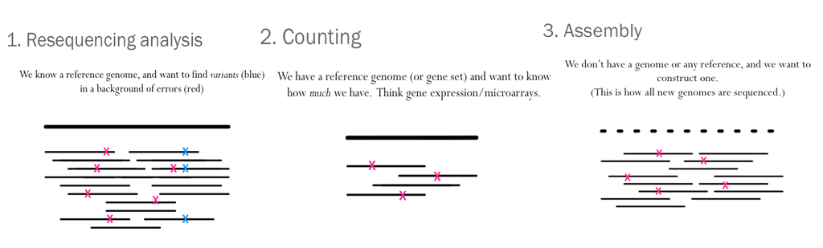

For that reason we have to do a QC check for our data. Basically, trimming tends to decrease sensitivity, while increasing specificity.

## Trimming low quality reads

There are different options to approach this part of the analysis: * Trimmomatic * FASTX-Toolkit * cutadapt

We will use a program called [Trimmomatic](http://www.usadellab.org/cms/?page=trimmomatic) to filter poor quality reads and trim poor quality bases from our samples.

```
#It is not available as module
#Let's activate our conda environment

module load python/anaconda-3.8
source /share/apps/bin/conda-3.8.sh

conda activate fastqc

# Now let's intall trimmomatic

conda install -c bioconda trimmomatic
```

Let’s check `trimmomatic`:

[output not shown]

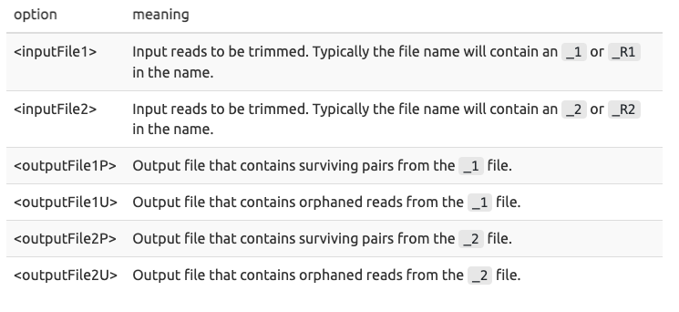

The last thing trimmomatic expects to see is the trimming parameters:

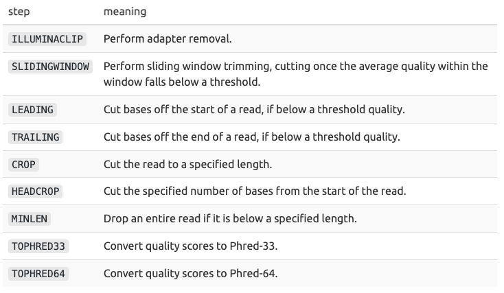

Let’s try this in our files:

```
trimmomatic PE -threads 4 Sacc.R1.fastq.gz Sacc.R2.fastq.gz  \
              Sacc.R1_paired.trimmed.fastq.gz Sacc.R1_unpaired.trimmed.fastq.gz \
              Sacc.R2_paired.trimmed.fastq.gz Sacc.R2_unpaired.trimmed.fastq.gz \
              SLIDINGWINDOW:4:20 \
              MINLEN:50 \
              ILLUMINACLIP:adapters.fa:2:30:10 \
```

The command above is a single line, but since some scripts or even the monitor could cut the command, you can use backslash `\` to break the command into multiple lines. Below I am going break down the command in parts to understand the whole process:

- `trimmomatic PE -threads 4 Sacc.R1.fastq Sacc.R2.fastq` - using trimmomatic in pair-end (PE) mode to use 4 threads and we specify the input files in order `R1` followed by `R2`
- `Sacc.R1_paired.trimmed.fastq.gz Sacc.R1_unpaired.trimmed.fastq.gz` - this part specifies two output files for reads in processed in `R1`: paired reads and unpaired reads.
- `Sacc.R2_paired.trimmed.fastq.gz Sacc.R2_unpaired.trimmed.fastq.gz` - this part specifies two output files for reads processed in `R2`: paired reads and unpaired reads.
- `SLIDINGWINDOW:4:20` - This parameter specifies the window analysis, `4` is how many bases to include in the sliding window and the **average** quality.
- `MINLEN:50` - This part specifies the minimum read length to keep, anything below is discarded
- `ILLUMINACLIP:adapters.fa:2:30:10` - This parameter specifies the option for trimming adapters (i.e. illumina nextera), the numbers in order are: mismatches allowed;palindrome; simple (This numbers are scores and suggested values range between 7-15 for simple and 30 for palindrome)

Ideally, this should be run as a script submitted to **SLURM**, in that case you should create a bash script using **nano** as follows: `nano trim_job.sh` (you can use any name). the contents of that file will be:

```
#SBATCH --job-name=trim_jarojas
#SBATCH --output=trim_job1.slurm
#SBATCH --nodes=1
#SBATCH --tasks-per-node=8
$SBATCH --time=00:05:00
#SBATCH --partition comp06

module load python/anaconda-3.8
source /share/apps/bin/conda-3.8.sh

conda activate fastqc

cd ~/Lecture_6

trimmomatic -threads 4 Sacc.R1.fastq.gz Sacc.R2.fastq.gz \
                       Sacc.R1_illumina.trimmed.fastq.gz Sacc.R1unpaired.trimmed.fastq.gz \
                       Sacc.R2_illumina.trimmed.fastq.gz Sacc.R2unpaired.trimmed.fastq.gz \
                       SLIDINGWINDOW:4:20 \
                       MINLEN:50 \
                       ILLUMINACLIP:adapters.fa:2:30:10
```

**Important note:** For the parameter illumina clip usually trimmomatic has folder that contains different examples of adapters used for illumina libraries:

- TruSeq2 (as used in GAII machines)
- TruSeq3 (as used by HiSeq and MiSeq machines)
- Nextera PE

Since we installed using conda, the files for those adapters are hidden in the conda environment `~/.conda/envs/fastqc/share/trimmomatic/adapters/`, however we can make a file containing all the adapters. Create a file named `adapters.fa` containing the following sequences:

```
>TruSeq3_IndexedAdapter
AGATCGGAAGAGCACACGTCTGAACTCCAGTCAC
>TruSeq3_UniversalAdapter
AGATCGGAAGAGCGTCGTGTAGGGAAAGAGTGTA

#TruSeq3-PE-2
>PrefixPE/1
TACACTCTTTCCCTACACGACGCTCTTCCGATCT
>PrefixPE/2
GTGACTGGAGTTCAGACGTGTGCTCTTCCGATCT
>PE1
TACACTCTTTCCCTACACGACGCTCTTCCGATCT
>PE1_rc
AGATCGGAAGAGCGTCGTGTAGGGAAAGAGTGTA
>PE2
GTGACTGGAGTTCAGACGTGTGCTCTTCCGATCT
>PE2_rc
AGATCGGAAGAGCACACGTCTGAACTCCAGTCAC

#TruSeq3-PE
>PrefixPE/1
TACACTCTTTCCCTACACGACGCTCTTCCGATCT
>PrefixPE/2
GTGACTGGAGTTCAGACGTGTGCTCTTCCGATCT

TruSeq3-SE
>TruSeq3_IndexedAdapter
AGATCGGAAGAGCACACGTCTGAACTCCAGTCAC
>TruSeq3_UniversalAdapter
AGATCGGAAGAGCGTCGTGTAGGGAAAGAGTGTA

#TruSeq2-SE
>TruSeq2_SE
AGATCGGAAGAGCTCGTATGCCGTCTTCTGCTTG
>TruSeq2_PE_f
AGATCGGAAGAGCGTCGTGTAGGGAAAGAGTGT
>TruSeq2_PE_r
AGATCGGAAGAGCGGTTCAGCAGGAATGCCGAG

#TruSeq2-PE
```

[output cut: 15 more lines]

```
TTTTTTTTTTCAAGCAGAAGACGGCATACGA

#Nextera
>PrefixNX/1
AGATGTGTATAAGAGACAG
>PrefixNX/2
AGATGTGTATAAGAGACAG
>Trans1
TCGTCGGCAGCGTCAGATGTGTATAAGAGACAG
>Trans1_rc
CTGTCTCTTATACACATCTGACGCTGCCGACGA
>Trans2
GTCTCGTGGGCTCGGAGATGTGTATAAGAGACAG
>Trans2_rc
CTGTCTCTTATACACATCTCCGAGCCCACGAGAC
```